# Good and Bad Plot

Chloe

2023-03-30

## Introduction

Today I will make a good and bad plot, by using a data set from the 1974 *Motor Trend* magazine publication on motor trend car road tests. 32 cars were studied, and I used 3 categories of automobile design.

### Load Data

```r
library(tidyverse)
library(here)
library(dplyr)
library(ggrepel) #repels data for easier viewing
library(reshape2) #used for circular data graph in the bad plot
```

### Inspect Data

```r
View(mtcars) #viewed car data
glimpse(mtcars)
```

```
## Rows: 32
## Columns: 11
## $ mpg  <dbl> 21.0, 21.0, 22.8, 21.4, 18.7, 18.1, 14.3, 24.4, 22.8, 19.2, 17.8,…
## $ cyl  <dbl> 6, 6, 4, 6, 8, 6, 8, 4, 4, 6, 6, 8, 8, 8, 8, 8, 8, 4, 4, 4, 4, 8,…
## $ disp <dbl> 160.0, 160.0, 108.0, 258.0, 360.0, 225.0, 360.0, 146.7, 140.8, 16…
## $ hp   <dbl> 110, 110, 93, 110, 175, 105, 245, 62, 95, 123, 123, 180, 180, 180…
## $ drat <dbl> 3.90, 3.90, 3.85, 3.08, 3.15, 2.76, 3.21, 3.69, 3.92, 3.92, 3.92,…
## $ wt   <dbl> 2.620, 2.875, 2.320, 3.215, 3.440, 3.460, 3.570, 3.190, 3.150, 3.…
## $ qsec <dbl> 16.46, 17.02, 18.61, 19.44, 17.02, 20.22, 15.84, 20.00, 22.90, 18…
## $ vs   <dbl> 0, 0, 1, 1, 0, 1, 0, 1, 1, 1, 1, 0, 0, 0, 0, 0, 0, 1, 1, 1, 1, 0,…
## $ am   <dbl> 1, 1, 1, 0, 0, 0, 0, 0, 0, 0, 0, 0, 0, 0, 0, 0, 0, 1, 1, 1, 0, 0,…
## $ gear <dbl> 4, 4, 4, 3, 3, 3, 3, 4, 4, 4, 4, 3, 3, 3, 3, 3, 3, 4, 4, 4, 3, 3,…
## $ carb <dbl> 4, 4, 1, 1, 2, 1, 4, 2, 2, 4, 4, 3, 3, 3, 4, 4, 4, 1, 2, 1, 1, 2,…
```

### Make a Bad Plot

Shown below is my bad plot with derived data from the cars data set. This plot is considered to be “bad” due to the following reasons:

- ambiguous & useless legend that shows information for a separate data category
- pie graph (automatic no-no)
- non-specific axis labels & plot title
- overwhelming colors used within the plot
- cluttered data labels that may also be overshadowed by plot colors
- unclear data points

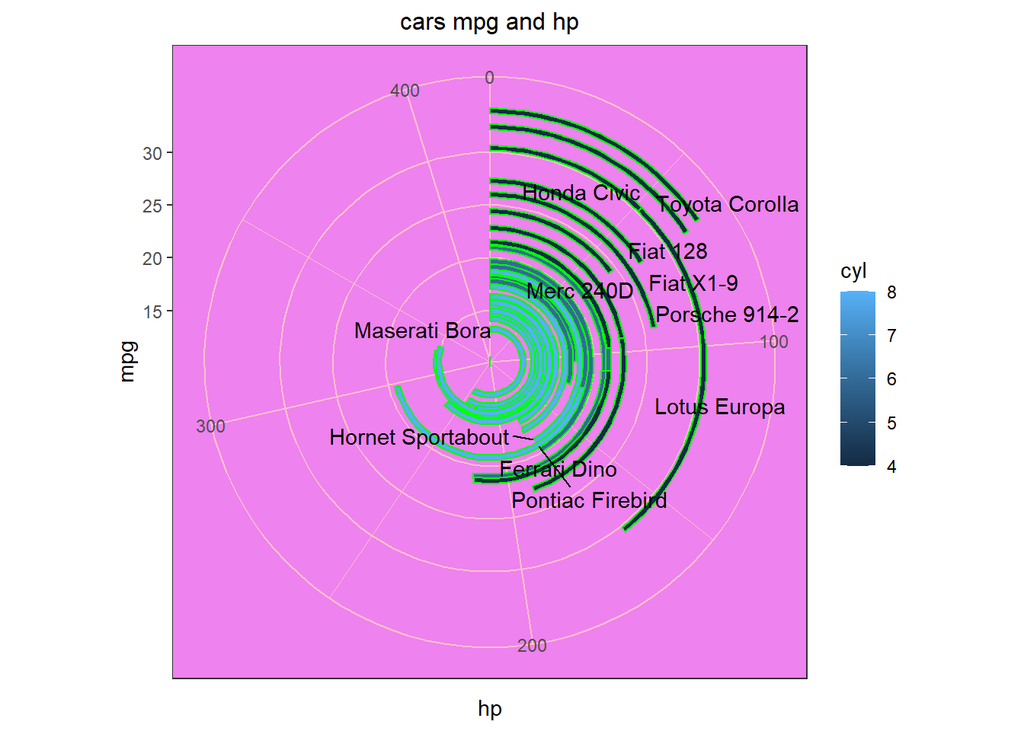

```r
mtcars %>%
  ggplot(aes(x = mpg,
             y = hp,
             fill = cyl,
             na.rm=FALSE,
             label = rownames(mtcars))) +
  theme_bw() +
  theme(plot.title = element_text(hjust = 0.5, size = 12),
        panel.grid = element_line(color = "pink"),
        panel.background = element_rect(fill = "violet"),
        legend.key = element_rect(color = "beige")) +
  geom_bar(width=0.5, stat="identity", color = "green") +
  coord_polar("y", start=0) + #combined coord_polar w/ geom_bar to create basic pie graph
  geom_text_repel() + #separated data
  ggtitle("cars mpg and hp")
```

```r
#to save the graph
ggsave(here("Good_Plot_Bad_Plot", "output", "badplot1.png"))
```

### Make a Good Plot

Below is my attempt at creating a good plot using the same car data. What makes this a good plot is:

- non-distracting color scheme
- a more specific plot title and axis labels
- the plot is easier to read than the first plot, although the data points could have been smaller and less crowded
- more of a useful graph for understanding the data

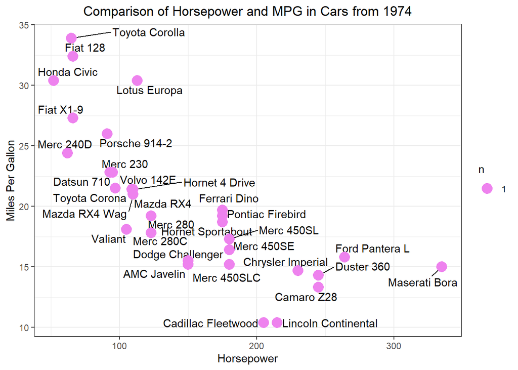

```r
ggplot(mtcars, aes(x = hp,
                   y = mpg,
                   label = rownames(mtcars))) +
  labs(x = "Horsepower",
       y = "Miles Per Gallon") +
  theme_bw() +
  geom_text_repel() + #repels to make text easy to read
  geom_count(color = 'violet') +
  ggtitle("Comparison of Horsepower and MPG in Cars from 1974") +
  theme(plot.title = element_text(hjust = 0.5))
```

```r
#save good plot
ggsave(here("Good_Plot_Bad_Plot", "output","goodplot.png"))
```